# Coursera ML Project - Human Activity Recognition

Jisun Kim

2/17/2019

## Introduction

The movement data from accelerometers on the belt, forearm, arm, and dumbell of 6 participants were collected. They were asked to perform barbell lifts correctly and incorrectly in 5 different ways. The objective of this practice is to predict the manner in which people did the exerise. Develop a model predicting the “classe” variable of 20 different test cases.

classes of the exercise Six young health participants were asked to perform one set of 10 repetitions of the Unilateral Dumbbell Biceps Curl in five different fashions: exactly according to the specification (Class A), throwing the elbows to the front (Class B), lifting the dumbbell only halfway (Class C), lowering the dumbbell only halfway (Class D) and throwing the hips to the front (Class E)

## Data and sources

the training data for this project are available here: https://d396qusza40orc.cloudfront.net/predmachlearn/pml-training.csv

The test data are available here: https://d396qusza40orc.cloudfront.net/predmachlearn/pml-testing.csv

The data for this project come from this source: http://web.archive.org/web/20161224072740/http:/groupware.les.inf.puc-rio.br/har.

## Data Load and Cleaning

```r
trainingData_raw <- read.csv("https://d396qusza40orc.cloudfront.net/predmachlearn/pml-training.csv")
testingData_raw <- read.csv("https://d396qusza40orc.cloudfront.net/predmachlearn/pml-testing.csv")
```

```r
library(caret)
library(knitr)
```

The original data include aggregated for each measures such as minimun, maximun, average etc. They are removed from the data since the columns have N/As and blanks, and don’t contribute to the modeling.  
Remove columns of which NAs or blank are grether or equal to 90% of data. Also column 1 through 7 have other information such as the subject names, time etc. which are not useful for prediction. They are also eliminated.

```r
dim(trainingData_raw)
```

```
## [1] 19622   160
```

```r
dim(testingData_raw)
```

```
## [1]  20 160
```

```r
#count of non NA data of each column
col_na_num_train <-  apply(trainingData_raw, 2, function(x) sum(is.na(x) | x == ""))
col_na_num_test <-  colSums(is.na(testingData_raw) | testingData_raw == "")
# Columns of which N/A are greater than or equal to 90% to the number of rows
rem_col_train <- which(col_na_num_train / dim(trainingData_raw)[1] >= 0.9)
rem_col_test <- which(col_na_num_test / dim(testingData_raw)[1] >= 0.9)

# Remove columns with 90% NAs
trainingData_ <- trainingData_raw[, -rem_col_train]
testingData_ <- testingData_raw[, -rem_col_test]

# Remove non-obsvervation columns
trainingData <- trainingData_[, -c(1:7)]
testingData <- testingData_[, -c(1:7)]
dim(trainingData)
```

```
## [1] 19622    53
```

```r
dim(testingData)
```

```
## [1] 20 53
```

```r
table(trainingData_raw$user_name, trainingData_raw$classe)
```

```
##
##               A    B    C    D    E
##   adelmo   1165  776  750  515  686
##   carlitos  834  690  493  486  609
##   charles   899  745  539  642  711
##   eurico    865  592  489  582  542
##   jeremy   1177  489  652  522  562
##   pedro     640  505  499  469  497
```

## Partitioning Training and Testing Data Set

Divide the cleaned training data to traing and test set to build and test models for the final test of the cleaned testing data.

```r
trainDataIndex <- createDataPartition(trainingData$classe, p = 0.6, list = FALSE)
trainData <- trainingData[trainDataIndex, ]
testData <- trainingData[-trainDataIndex, ]
dim(trainData)
```

```
## [1] 11776    53
```

```r
dim(testData)
```

```
## [1] 7846   53
```

## Modeling

### Classification Tree

```r
model_ctree <- train(classe ~., data = trainData, method = "rpart")

library(rattle)
```

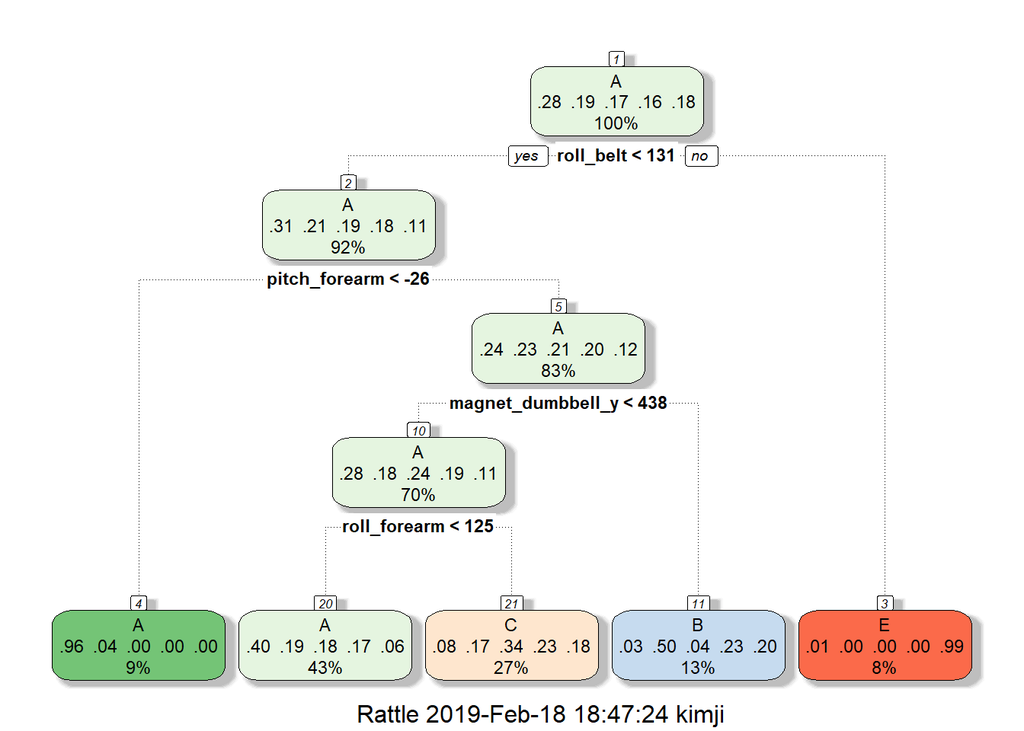

```r
fancyRpartPlot(model_ctree$finalModel)
```

```r
pred_ctree <- predict(model_ctree, newdata = testData)
confMatrix_ctree <- confusionMatrix(pred_ctree, testData$classe)
confMatrix_ctree
```

```
## Confusion Matrix and Statistics
##
##           Reference
## Prediction    A    B    C    D    E
##          A 2048  654  651  587  213
##          B   39  528   51  234  199
##          C  140  336  666  465  382
##          D    0    0    0    0    0
##          E    5    0    0    0  648
##
## Overall Statistics
##
##                Accuracy : 0.4958
##                  95% CI : (0.4847, 0.5069)
##     No Information Rate : 0.2845
##     P-Value [Acc > NIR] : < 2.2e-16
##
##                   Kappa : 0.3401
##  Mcnemar's Test P-Value : NA
##
## Statistics by Class:
##
##                      Class: A Class: B Class: C Class: D Class: E
## Sensitivity            0.9176   0.3478  0.48684   0.0000  0.44938
## Specificity            0.6250   0.9174  0.79577   1.0000  0.99922
## Pos Pred Value         0.4931   0.5024  0.33484      NaN  0.99234
## Neg Pred Value         0.9502   0.8543  0.88014   0.8361  0.88961
## Prevalence             0.2845   0.1935  0.17436   0.1639  0.18379
## Detection Rate         0.2610   0.0673  0.08488   0.0000  0.08259
## Detection Prevalence   0.5293   0.1340  0.25350   0.0000  0.08323
## Balanced Accuracy      0.7713   0.6326  0.64131   0.5000  0.72430
```

```r
confMatrix_ctree$overall
```

```
##       Accuracy          Kappa  AccuracyLower  AccuracyUpper   AccuracyNull
##      0.4957940      0.3400530      0.4846705      0.5069207      0.2844762
## AccuracyPValue  McnemarPValue
##      0.0000000            NaN
```

### Random Forest

```r
model_rf <- train(classe ~., data = trainData, method = "rf")

pred_rf <- predict(model_rf, newdata = testData)
confMatrix_rf <- confusionMatrix(pred_rf, testData$classe)

print(model_rf)
```

```
## Random Forest
##
## 11776 samples
##    52 predictor
##     5 classes: 'A', 'B', 'C', 'D', 'E'
##
## No pre-processing
## Resampling: Bootstrapped (25 reps)
## Summary of sample sizes: 11776, 11776, 11776, 11776, 11776, 11776, ...
## Resampling results across tuning parameters:
##
##   mtry  Accuracy   Kappa
##    2    0.9859065  0.9821693
##   27    0.9867010  0.9831766
##   52    0.9766606  0.9704759
##
## Accuracy was used to select the optimal model using the largest value.
## The final value used for the model was mtry = 27.
```

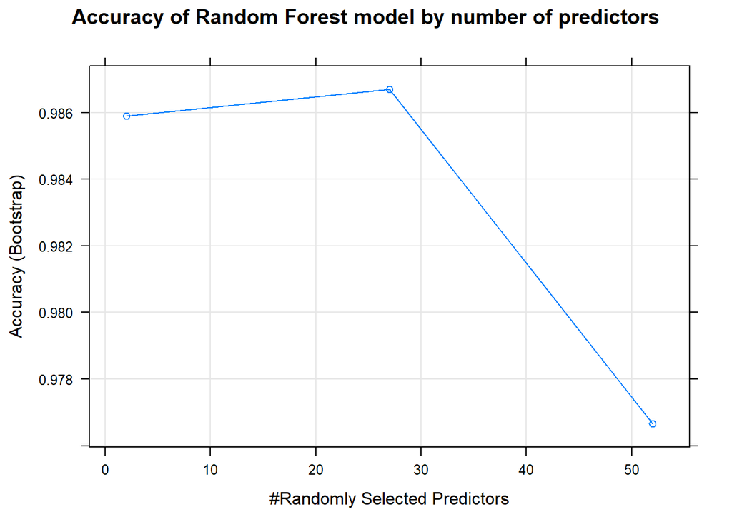

```r
plot(model_rf, main = "Accuracy of Random Forest model by number of predictors")
```

```r
confMatrix_rf
```

```
## Confusion Matrix and Statistics
##
##           Reference
## Prediction    A    B    C    D    E
##          A 2223   20    0    0    0
##          B    7 1487   20    4    0
##          C    1   11 1338   11    2
##          D    0    0   10 1270    6
##          E    1    0    0    1 1434
##
## Overall Statistics
##
##                Accuracy : 0.988
##                  95% CI : (0.9854, 0.9903)
##     No Information Rate : 0.2845
##     P-Value [Acc > NIR] : < 2.2e-16
##
##                   Kappa : 0.9848
##  Mcnemar's Test P-Value : NA
##
## Statistics by Class:
##
##                      Class: A Class: B Class: C Class: D Class: E
## Sensitivity            0.9960   0.9796   0.9781   0.9876   0.9945
## Specificity            0.9964   0.9951   0.9961   0.9976   0.9997
## Pos Pred Value         0.9911   0.9796   0.9817   0.9876   0.9986
## Neg Pred Value         0.9984   0.9951   0.9954   0.9976   0.9988
## Prevalence             0.2845   0.1935   0.1744   0.1639   0.1838
## Detection Rate         0.2833   0.1895   0.1705   0.1619   0.1828
## Detection Prevalence   0.2859   0.1935   0.1737   0.1639   0.1830
## Balanced Accuracy      0.9962   0.9873   0.9871   0.9926   0.9971
```

```r
confMatrix_rf$overall
```

```
##       Accuracy          Kappa  AccuracyLower  AccuracyUpper   AccuracyNull
##      0.9880194      0.9848433      0.9853584      0.9903079      0.2844762
## AccuracyPValue  McnemarPValue
##      0.0000000            NaN
```

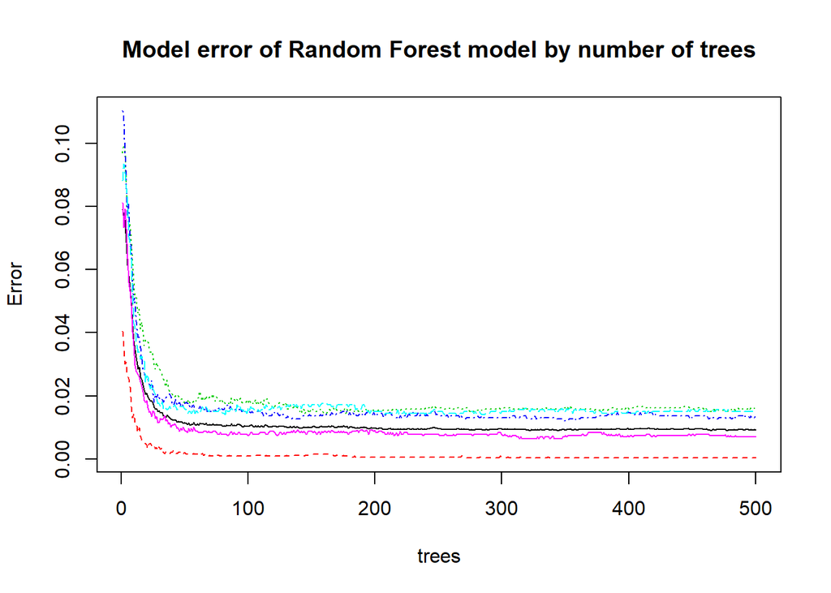

```r
# plotting the final model
plot(model_rf$finalModel, main = "Model error of Random Forest model by number of trees")
```

```r
# list of variables used for the model
names(model_rf$finalModel)
```

```
##  [1] "call"            "type"            "predicted"
##  [4] "err.rate"        "confusion"       "votes"
##  [7] "oob.times"       "classes"         "importance"
## [10] "importanceSD"    "localImportance" "proximity"
## [13] "ntree"           "mtry"            "forest"
## [16] "y"               "test"            "inbag"
## [19] "xNames"          "problemType"     "tuneValue"
## [22] "obsLevels"       "param"
```

```r
# Importance of the variables
importantVars <- varImp(model_rf)
importantVars
```

```
## rf variable importance
##
##   only 20 most important variables shown (out of 52)
##
##                      Overall
## roll_belt            100.000
## pitch_forearm         57.650
## yaw_belt              51.795
## pitch_belt            45.197
## magnet_dumbbell_y     42.733
## magnet_dumbbell_z     41.563
## roll_forearm          41.130
## accel_dumbbell_y      23.099
## roll_dumbbell         16.926
## magnet_dumbbell_x     16.610
## magnet_belt_z         16.524
## accel_forearm_x       16.505
## magnet_forearm_z      14.924
## accel_dumbbell_z      14.758
## total_accel_dumbbell  13.113
## magnet_belt_y         11.358
## accel_belt_z          11.343
## yaw_arm               10.674
## magnet_belt_x         10.268
## gyros_belt_z           9.621
```

### Support Vector Machine

```r
model_svm <- train(classe ~., data = trainData, method = "svmLinear")

pred_svm <- predict(model_svm, newdata = testData)
confMatrix_svm <- confusionMatrix(pred_svm, testData$classe)

confMatrix_svm
```

```
## Confusion Matrix and Statistics
##
##           Reference
## Prediction    A    B    C    D    E
##          A 2066  220  134   88   74
##          B   48 1078  138   63  193
##          C   52   91 1030  123  106
##          D   63   24   27  942   72
##          E    3  105   39   70  997
##
## Overall Statistics
##
##                Accuracy : 0.7791
##                  95% CI : (0.7698, 0.7883)
##     No Information Rate : 0.2845
##     P-Value [Acc > NIR] : < 2.2e-16
##
##                   Kappa : 0.7189
##  Mcnemar's Test P-Value : < 2.2e-16
##
## Statistics by Class:
##
##                      Class: A Class: B Class: C Class: D Class: E
## Sensitivity            0.9256   0.7101   0.7529   0.7325   0.6914
## Specificity            0.9081   0.9302   0.9426   0.9716   0.9661
## Pos Pred Value         0.8002   0.7092   0.7347   0.8351   0.8213
## Neg Pred Value         0.9685   0.9304   0.9475   0.9488   0.9329
## Prevalence             0.2845   0.1935   0.1744   0.1639   0.1838
## Detection Rate         0.2633   0.1374   0.1313   0.1201   0.1271
## Detection Prevalence   0.3291   0.1937   0.1787   0.1438   0.1547
## Balanced Accuracy      0.9169   0.8201   0.8477   0.8521   0.8288
```

```r
confMatrix_svm$overall
```

```
##       Accuracy          Kappa  AccuracyLower  AccuracyUpper   AccuracyNull
##   7.791231e-01   7.188947e-01   7.697775e-01   7.882610e-01   2.844762e-01
## AccuracyPValue  McnemarPValue
##   0.000000e+00   1.315813e-71
```

### Naive Bayes

```r
model_nb <- train(classe ~., data = trainData, method = "naive_bayes")

pred_nb <- predict(model_nb, newdata = testData)
confMatrix_nb <- confusionMatrix(pred_nb, testData$classe)

confMatrix_nb
```

```
## Confusion Matrix and Statistics
##
##           Reference
## Prediction    A    B    C    D    E
##          A 1668  125   73   74   32
##          B   69 1044  108   12  129
##          C  230  213 1148  264   95
##          D  247  110   32  878   49
##          E   18   26    7   58 1137
##
## Overall Statistics
##
##                Accuracy : 0.7488
##                  95% CI : (0.739, 0.7584)
##     No Information Rate : 0.2845
##     P-Value [Acc > NIR] : < 2.2e-16
##
##                   Kappa : 0.684
##  Mcnemar's Test P-Value : < 2.2e-16
##
## Statistics by Class:
##
##                      Class: A Class: B Class: C Class: D Class: E
## Sensitivity            0.7473   0.6877   0.8392   0.6827   0.7885
## Specificity            0.9458   0.9497   0.8762   0.9332   0.9830
## Pos Pred Value         0.8458   0.7665   0.5887   0.6672   0.9125
## Neg Pred Value         0.9040   0.9269   0.9627   0.9375   0.9538
## Prevalence             0.2845   0.1935   0.1744   0.1639   0.1838
## Detection Rate         0.2126   0.1331   0.1463   0.1119   0.1449
## Detection Prevalence   0.2513   0.1736   0.2485   0.1677   0.1588
## Balanced Accuracy      0.8466   0.8187   0.8577   0.8080   0.8857
```

```r
confMatrix_nb$overall
```

```
##       Accuracy          Kappa  AccuracyLower  AccuracyUpper   AccuracyNull
##   7.487892e-01   6.839729e-01   7.390374e-01   7.583558e-01   2.844762e-01
## AccuracyPValue  McnemarPValue
##   0.000000e+00  6.427345e-130
```

### Stochastic Gradient Boosting (method = ‘gbm’)

```r
garbage <- capture.output(
model_gbm <- train(classe ~., data = trainData, method = "gbm")
)

pred_gbm <- predict(model_gbm, newdata = testData)
confMatrix_gbm <- confusionMatrix(pred_gbm, testData$classe)
confMatrix_gbm
```

```
## Confusion Matrix and Statistics
##
##           Reference
## Prediction    A    B    C    D    E
##          A 2212   62    0    2    1
##          B   14 1413   59    8   14
##          C    3   39 1291   47    8
##          D    2    3   16 1220   13
##          E    1    1    2    9 1406
##
## Overall Statistics
##
##                Accuracy : 0.9613
##                  95% CI : (0.9567, 0.9654)
##     No Information Rate : 0.2845
##     P-Value [Acc > NIR] : < 2.2e-16
##
##                   Kappa : 0.951
##  Mcnemar's Test P-Value : 3.521e-11
##
## Statistics by Class:
##
##                      Class: A Class: B Class: C Class: D Class: E
## Sensitivity            0.9910   0.9308   0.9437   0.9487   0.9750
## Specificity            0.9884   0.9850   0.9850   0.9948   0.9980
## Pos Pred Value         0.9715   0.9370   0.9301   0.9729   0.9908
## Neg Pred Value         0.9964   0.9834   0.9881   0.9900   0.9944
## Prevalence             0.2845   0.1935   0.1744   0.1639   0.1838
## Detection Rate         0.2819   0.1801   0.1645   0.1555   0.1792
## Detection Prevalence   0.2902   0.1922   0.1769   0.1598   0.1809
## Balanced Accuracy      0.9897   0.9579   0.9644   0.9717   0.9865
```

```r
confMatrix_gbm$overall
```

```
##       Accuracy          Kappa  AccuracyLower  AccuracyUpper   AccuracyNull
##   9.612541e-01   9.509531e-01   9.567453e-01   9.654160e-01   2.844762e-01
## AccuracyPValue  McnemarPValue
##   0.000000e+00   3.521309e-11
```

## Comparing the performance of the prediction models

```r
result_table <- data.frame(
      Models = c("Classification Tree", "Random Forest", "Support Vector Machine", "Naive Bayes", "Stochastic Gradient Boosting"),
      Accuracy = c(confMatrix_ctree$overall[1], confMatrix_rf$overall[1], confMatrix_svm$overall[1], confMatrix_nb$overall[1], confMatrix_gbm$overall[1])
      )

kable(result_table, caption = "Performance of the Prediction Models")
```

Performance of the Prediction Models

[output not shown]

## Predicting the test data set

```r
final_pred_rf <- predict(model_rf, newdata = testingData)

final_pred_rf
```

```
##  [1] B A B A A E D B A A B C B A E E A B B B
## Levels: A B C D E
```

## Conclusion

The final prediction of the 20 entities are: B A B A A E D B A A B C B A E E A B B B